# Case Study1

Samira Zarandioon

March 13, 2017

# Introduction

In this report we analyze GDP ranking and distribution of 190 countries. Also, we study the relationship of the GDP with income groups.

To perform the analysis, using a make file, we first download the Gross Domestic product and the educational data sets and after the clean up we analyze the tidy data. These steps and the analysis results are documented in following sections.

# Data Prepration

Below the steps for preparing the data are listed:

1. Download the GDP data from [here](https://d396qusza40orc.cloudfront.net/getdata%2Fdata%2FGDP.csv).

   ```r
   # Makefile.R

   #install.packages("downloader")
   library(downloader)

   # downlaod the GDP data
   download("https://d396qusza40orc.cloudfront.net/getdata%2Fdata%2FGDP.csv", destfile="GDP.csv")
   ```

2. The GDP data set contains 331 rows and 10 column. There are 127 rows with missing GDP value and 141 with missing Rank value. After cleaning the data, the tidy data set contains 190 rows and four columns. The following steps are used to clean the GDP data:
   - Drop the empty columns
   - Give descriptive names to the remaining columns
   - Convert the GDP and Rank columns to numeric type
   - Drop the rows that their GDP or Rank is missing

   ```r
   # (from) Makefile.R

   # read the GDP data file and skip the first 5 rows
   GDP_dataframe <- read.csv("GDP.csv", stringsAsFactors=FALSE, header=FALSE)

   cat("Rows in the initial GDP data set = ", nrow(GDP_dataframe), "\n")
   ```

   ```
   ## Rows in the initial GDP data set =  331
   ```

   ```r
   # drop the empty columns
   GDP_dataframe <-GDP_dataframe[,c(1,2,4,5)]

   # give desciptive names to columns
   colnames(GDP_dataframe) = c("CountryCode","Rank","Country","GDP")

   # remove commos from GDP values and then convert them to numeric type
   GDP_dataframe$GDP <- as.numeric(gsub(",","",GDP_dataframe$GDP))

   # convert Rank to numeric type
   GDP_dataframe$Rank <- as.numeric(GDP_dataframe$Rank)

   # logic for handling missing value

   cat("Rows with missing GDP value = ", nrow(GDP_dataframe[is.na(GDP_dataframe$GDP),]), "\n" )
   ```

   ```
   ## Rows with missing GDP value =  127
   ```

   ```r
   cat("Rows with missing Rank value = ", nrow(GDP_dataframe[is.na(GDP_dataframe$Rank),]), "\n" )
   ```

   ```
   ## Rows with missing Rank value =  141
   ```

   ```r
   # remove rows with missing GDP or Rank values
   GDP_dataframe <- GDP_dataframe[complete.cases(GDP_dataframe$GDP) & complete.cases(GDP_dataframe$Rank),]

   cat("Rows in the tidy GDP data set = ", nrow(GDP_dataframe), "\n")
   ```

   ```
   ## Rows in the tidy GDP data set =  190
   ```

3. Download the educational data set from [here](https://d396qusza40orc.cloudfront.net/getdata%2Fdata%2FEDSTATS_Country.csv) and clean the data by removing the 24 rows with missing income group and keeping only the relevant columns (i.e. CountryCode and Income.Group). The clean data set has 210 rows.

   ```r
   download("https://d396qusza40orc.cloudfront.net/getdata%2Fdata%2FEDSTATS_Country.csv", destfile="EDSTATS_Country.csv")

   ED_dataframe <-read.csv("EDSTATS_Country.csv", stringsAsFactors=FALSE, header=TRUE)

   cat("Rows in the initial ED data set = ", nrow(ED_dataframe), "\n")
   ```

   ```
   ## Rows in the initial ED data set =  234
   ```

   ```r
   cat("Rows with missing Income.Group = ", nrow(ED_dataframe[is.na(ED_dataframe$Income.Group) | ED_dataframe$Income.Group == "" ,]), "\n" )
   ```

   ```
   ## Rows with missing Income.Group =  24
   ```

   ```r
   # remove rows with missing Income Group and keep only the relevant columns
   ED_dataframe <- ED_dataframe[ED_dataframe$Income.Group != "",c("CountryCode", "Income.Group")]
   cat("Rows in the tidy ED data = ", nrow(ED_dataframe), "\n")
   ```

   ```
   ## Rows in the tidy ED data =  210
   ```

4. Merge the data set containing GDP info with the data set containing info about income group by matching the country codes.

   ```r
   GDP_IncomeGroup_dataframe <- merge(x=GDP_dataframe,y=ED_dataframe, by="CountryCode", incomparables = NA)
   ```

# Data Analysis

We can use the tidy merged data set to collect the following information about distribution of GDPs and their relationship with income groups:

1. Number of matched rows across GDP and Income Group data set is *189*.

   ```r
   cat("Number of matched ids = ", nrow(GDP_IncomeGroup_dataframe), "\n")
   ```

   ```
   ## Number of matched ids =  189
   ```

2. The 13th country with lowest GDP is *St. Kitts and Nevis*.

   ```r
   # sort the rows in the data frame based on the GDP in ascending order.
   sorted_GDP_IncomeGroup_dataframe <- GDP_IncomeGroup_dataframe[order(GDP_IncomeGroup_dataframe$GDP, na.last = TRUE),]

   cat("The 13th country with lowest GDP is", sorted_GDP_IncomeGroup_dataframe[13,]$Country, ".\n")
   ```

   ```
   ## The 13th country with lowest GDP is St. Kitts and Nevis .
   ```

3. The average GDP rankings for the “High income: OECD” and “High income: nonOECD” groups are 1483917.13 and 104349.8 respectively.

   ```r
   avg_GDP_per_group <- aggregate(list(avg_GDP=GDP_IncomeGroup_dataframe$GDP), by=list(Group=GDP_IncomeGroup_dataframe$Income.Group), FUN=mean)

   OECD_avg_GDP <- avg_GDP_per_group[avg_GDP_per_group$Group == "High income: OECD", c("avg_GDP")]
   nonOECD_avg_GDP <- avg_GDP_per_group[avg_GDP_per_group$Group == "High income: nonOECD", c("avg_GDP")]

   cat("Average GDP rankings for the High income: OECD = ",  OECD_avg_GDP, "\n")
   ```

   ```
   ## Average GDP rankings for the High income: OECD =  1483917
   ```

   ```r
   cat("Average GDP rankings for the High income: nonOECD = ", nonOECD_avg_GDP, "\n")
   ```

   ```
   ## Average GDP rankings for the High income: nonOECD =  104349.8
   ```

4. The following plot shows the distribution of GDP value for all the countries, color coded by income groups:

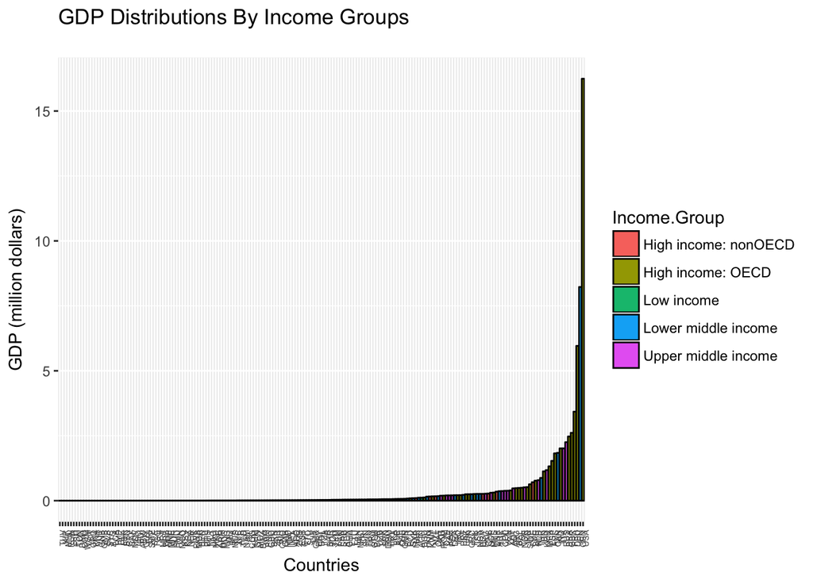

   ```r
   #install.packages("ggplot2")
   library(ggplot2)
   ggplot(GDP_IncomeGroup_dataframe, aes(x=reorder(CountryCode, GDP), y=GDP/10^6)) +
     geom_bar(aes(fill=Income.Group),   # fill depends on income group
          stat="identity",
          colour="black",    # Black outline for all
          position=position_dodge()) + # Put bars side-by-side instead of stacked
     theme(axis.text.x = element_text(angle = 90, hjust = 1, size = 5)) +
     labs(title = "GDP Distributions By Income Groups\n", x="Countries",y="GDP (million dollars)", colour = "Income Groups\n")
   ```

5. Summary statistics of GDP by income groups are as follows:

   ```r
   summary_GDP_per_group <- aggregate(list(GDP=GDP_IncomeGroup_dataframe$GDP), by=list(Group=GDP_IncomeGroup_dataframe$Income.Group), FUN=function(x) c(Min=min(x), Mean=mean(x), Max=max(x), Sd=sd(x)))
   summary_GDP_per_group
   ```

   ```
   ##                  Group     GDP.Min    GDP.Mean     GDP.Max      GDP.Sd
   ## 1 High income: nonOECD     2584.00   104349.83   711050.00   165334.45
   ## 2    High income: OECD    13579.00  1483917.13 16244600.00  3070463.52
   ## 3           Low income      596.00    14410.78   116355.00    20473.09
   ## 4  Lower middle income       40.00   256663.48  8227103.00  1139619.92
   ## 5  Upper middle income      228.00   231847.84  2252664.00   476872.04
   ```

6. Number of countries that are Lower middle income but among the 38 nations with highest GDP is 4.

   ```r
   #install.packages("dplyr")
   library(dplyr)
   # add a new variable that indicates the quantile of each row
   GDP_IncomeGroup_dataframe$quantile <- ntile(GDP_IncomeGroup_dataframe$GDP, 5)

   # select the rows that are in the fifth quantile and also are Lower middle income
   middle_income_hieget_GDPs_df <- GDP_IncomeGroup_dataframe[GDP_IncomeGroup_dataframe$quantile==5 & GDP_IncomeGroup_dataframe$Income.Group=="Lower middle income",]

   cat("Number of countries that are Lower middle income but among the 38 nations with highest GDP (quantile 5): ", nrow(middle_income_hieget_GDPs_df))
   ```

   ```
   ## Number of countries that are Lower middle income but among the 38 nations with highest GDP (quantile 5):  4
   ```

# Summary

In this report we analyzed the distribution of GDP of 190 countries and studied their relationship with income group. Moreover, we provided the steps for reproducing the results including the steps for collection and cleaning the raw data.